```python
import dependencies

import numpy as np

from hvac.components import ControlValve
from nummath import graphing
```

# EFFECTIEVE KLEPKARAKTERISTIEK VAN EEN TWEEWEGREGELKLEP

De effectieve klepkarakteristiek drukt het verband uit tussen de relatieve klepstand en het relatief volumedebiet dat een geïnstalleerde regelklep in een leidingnetwerk doorlaat. De relatieve klepstand is de klepstand uitgedrukt als een fractie of percentage van het totale bereik. 0% betekent dat de klep volledig dicht is en 100% betekent dat de klep volledig open is. Het relatieve volumedebiet is het volumedebiet uitgedrukt als een fractie of percentage van het volumedebiet dat de geïnstalleerde regelklep zou doorlaten als deze volledig geopend is. Het verloop van de effectieve klepkarakteristiek wordt bepaald door de klepautoriteit die de geïnstalleerde regelklep bezit. Klepautoriteit wordt gedefinieerd als de verhouding van de drukval over de volledig geopende klep op de drukval over de regelklep wanneer deze volledig dichtstaat. Het is geen inherent kenmerk van de regelklep, maar hangt af van het leidingnetwerk waarin de regelklep is geïnstalleerd.

Hiernavolgend worden de effectieve klepkarakteristieken van een equiprocentuele regelklep berekend voor verschillende waarden van de klepautoriteit.

**Maak een reeks van equiprocentuele tweewegregelkleppen aan met een verschillende klepautoriteit**

```python
# definieer een reeks van klepautoriteiten gaande van 0,2 tot en met 1 met een stap van 0,2
a_array = np.arange(0.2, 1.2, 0.2)

# geef het inherent regelbereik van de equiprocentuele regelklep op
R = 150.0

# creëer voor elke klepautoriteit een regelklep met die klepautoriteit
control_valve_list = [ControlValve(a, R, 1.0) for a in a_array]
```

**Bereken van elke regelklep de procentuele effectieve klepkarakteristiek**

```python
# definieer het bereik van de klepstand tussen 0 % en 100 % open
h_percent_range = np.linspace(0.0, 100.0, endpoint=True)

# bereken van elke regelklep het procentueel volumedebiet bij elke klepstand van de regelklep
Vw_percent_list = [control_valve_list[i].characteristic(h_percent_range) for i in range(len(control_valve_list))]
```

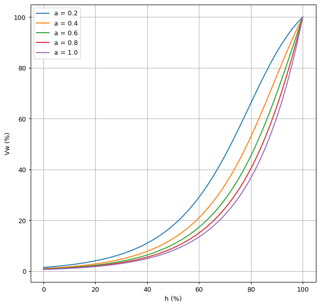

```python
graph = graphing.Graph(fig_size=[8.0, 8.0], dpi=90)
for i in range(len(Vw_percent_list)):
    graph.add_data_set(f'a = {a[i]:.1f}', h_percent_range, Vw_percent_list[i])
graph.set_axis_titles('h (%)', 'Vw (%)')
graph.add_legend()
graph.turn_grid_on()
graph.draw_graph()
graph.show_graph()
```

**Noot**  
Een klepautoriteit `a` van 1 levert de procentuele inherente klepkarakteristiek op.